# Practice Problems 1

Author

David Trinh

**Due Friday, 9/13 at 5pm on Moodle.**

# Purpose

The goal of this set of practice problems is to practice the following skills:

- Constructing and interpreting visualizations that inform research questions of interest
- Data wrangling
- Constructing and interpreting simple linear regression models

**You can download a template to start from here.**

# Directions

1. We will be using data from the `fivethirtyeight` package. Install this package by entering the `install.packages()` command in the **Console**. (Do not include the installation command in this file–your document won’t render to the required HTML file!)
2. Create a code chunk in which you load the `ggplot2`, `dplyr`, and `fivethirtyeight` packages.
3. Continue with the exercises below. You will need to create new code chunks to construct visualizations and models and write interpretations beneath. Put text responses in blockquotes as shown below:

> Response here. (The > at the start of the line starts a blockquote and makes the text larger and easier to read.)
4. Render your work for submission:
   - Click the “Render” button in the menu bar for this pane (blue arrow pointing right). This will create an HTML file containing all of the directions, code, and responses from this activity. A preview of the HTML will appear in the browser.
   - Scroll through and inspect the document to check that your work translated to the HTML format correctly.
   - Close the browser tab.
   - Go to the “Background Jobs” pane in RStudio and click the Stop button to end the rendering process.
   - Locate the rendered HTML file in the folder where this file is saved. Open the HTML to ensure that your work looks as it should (code appears, output displays, interpretations appear). Upload this HTML file to Moodle.

# Exercises

## Context

This cartoon by Alison Bechdel inspired the “Bechdel test” (image source):

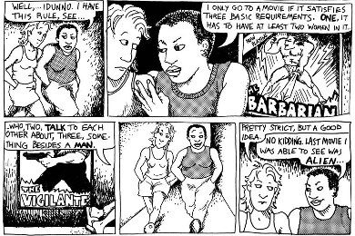

A movie passes the test if it meets the following criteria:

- there are at least 2 women-identifying characters;
- these characters talk to each other at least 1 time; and
- they talk about something other than a male-identifying character

We’ll work with the `bechdel` data within the `fivethirtyeight` package. You can enter `?bechdel` in the Console to view the codebook.

```r
# Load the data
library(tidyverse)
library(fivethirtyeight)
data(bechdel)
```

## Exercise 1: Define two new variables

We can use the `mutate()` function from `dplyr` to define new variables. For example:

```r
# Define a new variable which measures years_since_1900
bechdel <- bechdel %>%
    mutate(years_since_1900 = year - 1900)

# Check it out / confirm it's right
bechdel %>%
    select(year, years_since_1900) %>%
    head(3)
```

```
# A tibble: 3 × 2
   year years_since_1900
  <int>            <dbl>
1  2013              113
2  2012              112
3  2013              113
```

Your turn. Define a new variable `budget_mil` which measures budget in MILLIONS of dollars (on the 2013 scale). Similarly, define a new variable `intgross_mil` which measures international gross in MILLIONS of dollars (on the 2013 scale). Store these in `bechdel` and confirm your results match those here:

```r
bechdel <- bechdel %>%
    mutate(budget_mil = budget_2013 / 1000000) %>%
    mutate(intgross_mil = intgross_2013 / 1000000)

# Check it out / confirm it's right
bechdel %>%
    select(budget_mil, intgross_mil) %>%
    head(3)
```

```
# A tibble: 3 × 2
  budget_mil intgross_mil
       <dbl>        <dbl>
1       13           42.2
2       45.7         41.5
3       20          159.
```

```
## # A tibble: 3 x 2
##   budget_mil intgross_mil
##        <dbl>        <dbl>
## 1       13           42.2
## 2       45.7         41.5
## 3       20          159.
```

## Exercise 2: Get to know the data

Complete each task below using `dim()`, `nrow()`, `head()`, or one of the `dplyr` functions: `filter()`, `summarize()`, `select()`. For any questions about movie budget and gross earnings, use `budget_mil` and `gross_mil`. NOTE: You don’t need to write out any discussion for this exercise, just include your code and output.

```r
# How many films are in the dataset?
nrow(bechdel)
```

```
[1] 1794
```

```r
# When was the oldest film in the dataset made?
bechdel %>%
    summarize(min(year))
```

```
# A tibble: 1 × 1
  `min(year)`
        <int>
1        1970
```

```r
# When was the most recent film in the dataset made?
bechdel %>%
    summarize(max(year))
```

```
# A tibble: 1 × 1
  `max(year)`
        <int>
1        2013
```

```r
# What is the median film budget in 2013 dollars?
bechdel %>%
    summarize(median(budget_2013))
```

```
# A tibble: 1 × 1
  `median(budget_2013)`
                  <dbl>
1              36995786
```

```r
# What films had budgets that exceeded 300 million in 2013 dollars?
# (Just show the films and budgets, not all variables)
bechdel %>%
    filter(budget_mil >= 300) %>%
    select(title, budget_mil)
```

```
# A tibble: 3 × 2
  title                                    budget_mil
  <chr>                                         <dbl>
1 Avatar                                         461.
2 Pirates of the Caribbean: At World's End       337.
3 Shaft                                          305.
```

```r
# What films were made in 1971?
# (Just show the films and year, not all variables)

bechdel %>%
    filter(year == 1971) %>%
    select(title, year)
```

```
# A tibble: 5 × 2
  title                                year
  <chr>                               <int>
1 Escape from the Planet of the Apes   1971
2 Shaft                                1971
3 Straw Dogs                           1971
4 The French Connection                1971
5 Willy Wonka & the Chocolate Factory  1971
```

```r
# What were the budget_mil and intgross_mil values for "Titanic"?
# (Just show the budget_mil and intgross_mil values)
bechdel %>%
    filter(title == "Titanic") %>%
    select(budget_mil, intgross_mil)
```

```
# A tibble: 1 × 2
  budget_mil intgross_mil
       <dbl>        <dbl>
1       290.        3172.
```

## Exercise 3: Does it pass the Bechdel?

The `clean_test` variable records the Bechdel category into which each movie falls. From worst to best (if you care about the representation of women in film):

- `nowomen` = there are no significant women characters in the film
- `notalk` = there are women characters but they don’t talk to one another
- `men` = there are women characters that talk to one another but they only talk about men
- `dubious` = barely passes the Bechdel test
- `ok` = passes the Bechdel test

Construct a visualization of the `clean_test` variable, and construct a corresponding table of counts. In one sentence, summarize your findings about `clean_test` as if you were writing a newspaper article about movies.

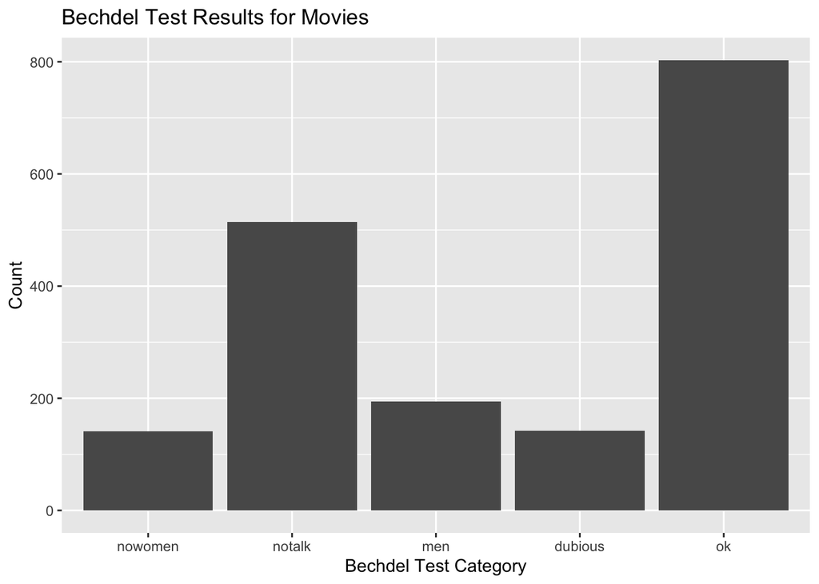

```r
ggplot(bechdel, aes(x = clean_test)) +
    geom_bar() +
    labs(title = "Bechdel Test Results for Movies",
         x = "Bechdel Test Category",
         y = "Count")
```

```r
num_ok <- bechdel %>%
    filter(clean_test == "ok") %>%
    nrow()

num_ok / nrow(bechdel)
```

```
[1] 0.4476031
```

```r
no_talk <- bechdel %>%
    filter(clean_test == "notalk") %>%
    nrow()

no_talk / nrow(bechdel)
```

```
[1] 0.2865106
```

## Exercise 4: How much money did it make?

The `intgross_mil` variable records each movie’s total international gross, in millions of dollars (and adjusted to 2013).

1. Construct a visualization of the `intgross_mil` variable. Summarize your findings as if you were writing a newspaper article about movies.

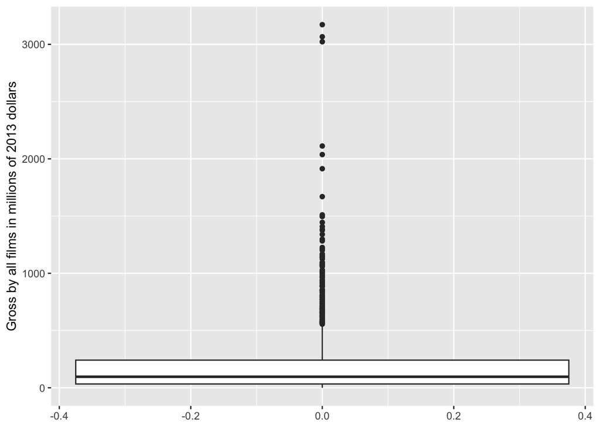

```r
ggplot(bechdel, aes(y = intgross_mil)) +
    geom_boxplot() +
    labs(y = "Gross by all films in millions of 2013 dollars")
```

2. Calculate the mean and median values of `intgross_mil`. Explain why the mean exceeds the median by quite a bit *and* which is the more appropriate measure of trend here.
   - NOTE: Since some films are missing information on `intgross_mil`, you’ll need to use `mean(___, na.rm = TRUE)` where `na.rm = TRUE` says to remove the NA (missing) values from the calculation. Similarly for the median.

```r
mean(bechdel$intgross_mil, na.rm = TRUE)
```

```
[1] 197.838
```

```r
median(bechdel$intgross_mil, na.rm = TRUE)
```

```
[1] 96.23964
```

##### The mean exceeds the median because of the uneven distribution of gross. In this case, few outliers at the high end with extremely high gross pull the average up. Whereas the majority of films hover around the bottom with below average gross.

3. Calculate the standard deviations for the `intgross_mil` and `budget_mil` variables. Comment on whether there’s more variability among how much money is spent *making* movies (budgets) or how much money a movie makes (grosses)?

```r
bechdel %>%
  summarize(sd(intgross_mil,  na.rm = TRUE))
```

```
# A tibble: 1 × 1
  `sd(intgross_mil, na.rm = TRUE)`
                             <dbl>
1                             284.
```

```r
bechdel %>%
  summarize(sd(budget_mil))
```

```
# A tibble: 1 × 1
  `sd(budget_mil)`
             <dbl>
1             54.9
```

##### The standard deviation for intgross is higher, indicating a higher variability in intgross compared to budget.

## Exercise 5: Explaining `intgross_mil`

Next, let’s try to *explain* some of the variability in how much money films gross. To this end, we’ll focus on modeling `intgross_mil` by `budget_mil`. That is, to what extent is the money a film makes related to its budget?

1. In the relationship between `intgross_mil` and `budget_mil`, which is the *response* variable?

##### The response value is intgross_mil because it measures the success of the film after being produced on budget_mil. Films with higher budgets tend to have higher quality and better marketing, which implies a higher chance of success in the market.

2. Construct a visualization of the relationship between `intgross_mil` and `budget_mil`. Include a regression line that represents the *trend* in this relationship.

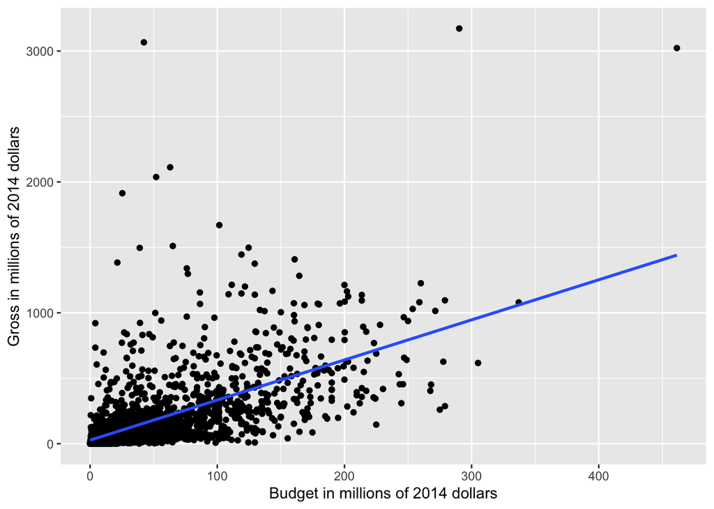

```r
bechdel %>%
  ggplot(aes(x = budget_mil, y = intgross_mil)) +
  geom_point() +
  geom_smooth(method = "lm", se = FALSE) +
  labs(x = "Budget in millions of 2014 dollars", y = "Gross in millions of 2014 dollars")
```

3. In 1-3 sentences, summarize your findings about this relationship as if you were writing a newspaper article about movies. Be sure to comment on both the *trend* and *variability* in this relationship.

##### The data and the derived linear regression curve suggest a positive correlation relationship between budget_mil and intgross_mil.

## Exercise 6: Modeling `intgross_mil`

Let’s examine the relationship between `intgross_mil` and `budget_mil` in more detail.

1. Use `lm()` to construct a linear regression model of the *trend* in the relationship between `intgross_mil` and `budget_mil`. Store this as `movie_model` and report a model summary table.

```r
movie_model <- lm(intgross_mil ~ budget_mil, bechdel)
movie_model %>%
  summary()
```

```
Call:
lm(formula = intgross_mil ~ budget_mil, data = bechdel)

Residuals:
    Min      1Q  Median      3Q     Max
-609.51  -88.28  -35.25   22.23 2909.81

Coefficients:
            Estimate Std. Error t value Pr(>|t|)
(Intercept)  27.1390     7.6938   3.527  0.00043 ***
budget_mil    3.0631     0.0983  31.163  < 2e-16 ***
---
Signif. codes:  0 '***' 0.001 '**' 0.01 '*' 0.05 '.' 0.1 ' ' 1

Residual standard error: 228.1 on 1781 degrees of freedom
  (11 observations deleted due to missingness)
Multiple R-squared:  0.3529,    Adjusted R-squared:  0.3525
F-statistic: 971.1 on 1 and 1781 DF,  p-value: < 2.2e-16
```

2. Write out a formula for the trend.

##### intgross_mil = 3.06 * budget_mil + 27.14

3. Provide a newspaper appropriate interpretation of the `budget_mil` coefficient. *Make sure to use non-causal language, include units, and talk about averages rather than individual cases.*

4. Does it make sense to interpret the intercept in this model? Explain.

##### Not in particular. The intercept is too significant in some cases (movies with low gross) and too insignificant in other cases (movies with thousands of millions in gross).

## Exercise 7: Predictions and residuals

1. In exercise 2 you identified the budget (`budget_mil`) for the movie *Titanic*. Use the model formula above to predict its international gross. You can check your work using the `predict()` function. This provides a more accurate prediction (it doesn’t round the model coefficients) so don’t worry if your calculation doesn’t exactly match.

##### intgross_mil_pred = 3.06 * budget_mil + 27.14

##### intgross_mil_pred = 3.06 * 290 + 27.14

##### intgross_mil_pred = 914.54

```r
predict(movie_model, newdata = data.frame(budget_mil = 290))
```

[output not shown]

2. Calculate the Titanic *residual*. HINT: You’ll need to use the observed `intgross_mil` value from exercise 2.

##### residual = intgross_mil_true - intgross_mil_pred

##### residual = 3171.931 - 915.4517

##### residual = 3171.931 - 915.4517

##### residual = 2256.479

```r
intgross_mil_true <- bechdel %>%
  filter(title == "Titanic") %>%
  select(intgross_mil)

intgross_mil_pred <- predict(movie_model, newdata = data.frame(budget_mil = 290))

intgross_mil_true - intgross_mil_pred
```

```
  intgross_mil
1     2256.479
```

3. Based on your calculation in part b, did the model over- or under-estimate *Titanic*’s gross?

##### Because the residual was positive, the model under-estimated Titanic’s gross.